# Bayesian GLM Part2

Author

Murray Logan

Published

09/09/2025

# 1 Preparations

Load the necessary libraries

```r
library(tidyverse) # for data wrangling etc
library(rstanarm) # for fitting models in STAN
library(cmdstanr) # for cmdstan
library(brms) # for fitting models in STAN
library(coda) # for diagnostics
library(bayesplot) # for diagnostics
library(ggmcmc) # for MCMC diagnostics
library(DHARMa) # for residual diagnostics
library(rstan) # for interfacing with STAN
library(emmeans) # for marginal means etc
library(broom) # for tidying outputs
library(tidybayes) # for more tidying outputs
library(ggeffects) # for partial plots
library(broom.mixed) # for summarising models
library(ggeffects) # for partial effects plots
library(bayestestR) # for ROPE
library(see) # for some plots
library(easystats) # for the easystats ecosystem
library(INLA) # for approximate Bayes
library(INLAutils) # for additional INLA outputs
library(patchwork) # for multiple plots
library(modelsummary) # for data and model summaries
theme_set(theme_grey()) # put the default ggplot theme back
source("helperFunctions.R")
```

# 2 Scenario

Polis et al. (1998) were interested in modelling the presence/absence of lizards (*Uta sp.*) against the perimeter to area ratio of 19 islands in the Gulf of California.

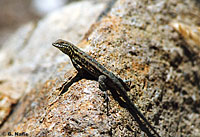

**Figure** 1: Uta lizard

**Table** 1: Format of polis.csv data file

| ISLAND | RATIO | PA |
| --- | --- | --- |
| Bota | 15.41 | 1 |
| Cabeza | 5.63 | 1 |
| Cerraja | 25.92 | 1 |
| Coronadito | 15.17 | 0 |
| .. | .. | .. |

**Table** 2: Description of the variables in the polis data file

| **ISLAND** | Categorical listing of the name of the 19 islands used - variable not used in analysis. |
| --- | --- |
| **RATIO** | Ratio of perimeter to area of the island. |
| **PA** | Presence (1) or absence (0) of *Uta* lizards on island. |

The aim of the analysis is to investigate the relationship between island perimeter to area ratio and the presence/absence of Uta lizards.

# 3 Read in the data

```r
polis <- read_csv("../data/polis.csv", trim_ws = TRUE)
```

**glimpse**

```r
glimpse(polis)
```

```
Rows: 19
Columns: 3
$ ISLAND <chr> "Bota", "Cabeza", "Cerraja", "Coronadito", "Flecha", "Gemelose"…
$ RATIO  <dbl> 15.41, 5.63, 25.92, 15.17, 13.04, 18.85, 30.95, 22.87, 12.01, 1…
$ PA     <dbl> 1, 1, 1, 0, 1, 0, 0, 0, 0, 1, 1, 1, 1, 0, 0, 0, 0, 1, 1
```

**head**

```r
## Explore the first 6 rows of the data
head(polis)
```

```
# A tibble: 6 × 3
  ISLAND     RATIO    PA
  <chr>      <dbl> <dbl>
1 Bota       15.4      1
2 Cabeza      5.63     1
3 Cerraja    25.9      1
4 Coronadito 15.2      0
5 Flecha     13.0      1
6 Gemelose   18.8      0
```

**str**

```r
str(polis)
```

```
spc_tbl_ [19 × 3] (S3: spec_tbl_df/tbl_df/tbl/data.frame)
 $ ISLAND: chr [1:19] "Bota" "Cabeza" "Cerraja" "Coronadito" ...
 $ RATIO : num [1:19] 15.41 5.63 25.92 15.17 13.04 ...
 $ PA    : num [1:19] 1 1 1 0 1 0 0 0 0 1 ...
 - attr(*, "spec")=
  .. cols(
  ..   ISLAND = col_character(),
  ..   RATIO = col_double(),
  ..   PA = col_double()
  .. )
 - attr(*, "problems")=<externalptr>
```

**Easystats (datawizard)**

```r
polis |> datawizard::data_codebook()
```

```
polis (19 rows and 3 variables, 3 shown)

ID | Name   | Type      | Missings |        Values |          N
---+--------+-----------+----------+---------------+-----------
1  | ISLAND | character | 0 (0.0%) |      Angeldlg |  1 ( 5.3%)
   |        |           |          |       Bahiaan |  1 ( 5.3%)
   |        |           |          |       Bahiaas |  1 ( 5.3%)
   |        |           |          |        Blanca |  1 ( 5.3%)
   |        |           |          |          Bota |  1 ( 5.3%)
   |        |           |          |        Cabeza |  1 ( 5.3%)
   |        |           |          |       Cerraja |  1 ( 5.3%)
   |        |           |          |    Coronadito |  1 ( 5.3%)
   |        |           |          |        Flecha |  1 ( 5.3%)
   |        |           |          |      Gemelose |  1 ( 5.3%)
   |        |           |          |         (...) |
---+--------+-----------+----------+---------------+-----------
2  | RATIO  | numeric   | 0 (0.0%) | [0.21, 63.16] |         19
---+--------+-----------+----------+---------------+-----------
3  | PA     | numeric   | 0 (0.0%) |             0 |  9 (47.4%)
   |        |           |          |             1 | 10 (52.6%)
---------------------------------------------------------------
```

**Skim (modelsummary)**

Unique

Missing Pct.

Mean

SD

Min

Median

Max

Histogram

RATIO

19

0

18.7

17.5

0.2

15.2

63.2

[figure not shown]

PA

2

0

0.5

0.5

0.0

1.0

1.0

[figure not shown]

ISLAND

N

%

Angeldlg

1

5.3

Bahiaan

1

5.3

Bahiaas

1

5.3

Blanca

1

5.3

Bota

1

5.3

Cabeza

1

5.3

Cerraja

1

5.3

Coronadito

1

5.3

Flecha

1

5.3

Gemelose

1

5.3

Gemelosw

1

5.3

Jorabado

1

5.3

Mejia

1

5.3

Mitlan

1

5.3

Pata

1

5.3

Pescador

1

5.3

Piojo

1

5.3

Smith

1

5.3

Ventana

1

5.3

```r
polis |> modelsummary::datasummary_skim()
```

# 4 Exploratory data analysis

The individual responses ($y_i$, observed presence/absence of Uta lizards) are each expected to have been **independently** drawn from Bernoulli (or binomial) distributions ($\mathcal{Bin}$). These distributions represent all the possible presence/absences we could have obtained at the specific ($i^th$) level of island perimeter to area ratio. Hence the $i^th$ presence/absence observation is expected to have been drawn from a binomial distribution with a probability of $\mu_i$ and size of ($n=1$).

The expected probabilities are related to the linear predictor (intercept plus slope associated with perimeter to area ratio) via a **logit** link.

We need to supply priors for each of the parameters to be estimated ($\beta_0$ and $\beta_1$). Whilst we want these priors to be sufficiently vague as to not influence the outcomes of the analysis (and thus be equivalent to the frequentist analysis), we do not want the priors to be so vague (wide) that they permit the MCMC sampler to drift off into parameter space that is both illogical as well as numerically awkward.

As a starting point, lets assign the following priors:

Model formula:
$$\begin{align}
y_i &\sim{} \mathcal{Bin}(n, \pi_i)\\
OR \\
y_i &\sim{} \mathcal{Bernoulli}(\pi_i)\\
ln\left(\frac{\pi_i}{1-\pi_i}\right) &= \beta_0 + \beta_1 x_i\\
\beta_0 &\sim{} \mathcal{N}(0, 1)\\
\beta_1 &\sim{} \mathcal{N}(0, 1)\\
\end{align}$$

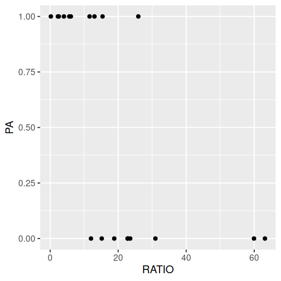

```r
ggplot(polis, aes(y = PA, x = RATIO)) +
  geom_point()
```

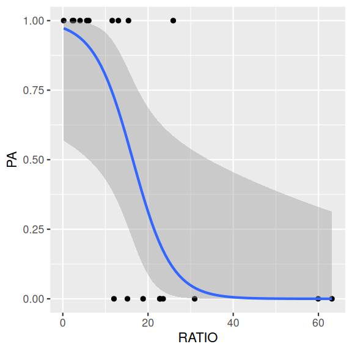

```r
ggplot(polis, aes(y = PA, x = RATIO)) +
  geom_point() +
  geom_smooth(
    method = "glm", formula = y ~ x,
    method.args = list(family = "binomial")
  )
```

# 5 Fit the model

**frequentist**

```r
summary(glm(PA ~ RATIO, data = polis, family = binomial()))
```

```
Call:
glm(formula = PA ~ RATIO, family = binomial(), data = polis)

Coefficients:
            Estimate Std. Error z value Pr(>|z|)
(Intercept)   3.6061     1.6953   2.127   0.0334 *
RATIO        -0.2196     0.1005  -2.184   0.0289 *
---
Signif. codes:  0 '***' 0.001 '**' 0.01 '*' 0.05 '.' 0.1 ' ' 1

(Dispersion parameter for binomial family taken to be 1)

    Null deviance: 26.287  on 18  degrees of freedom
Residual deviance: 14.221  on 17  degrees of freedom
AIC: 18.221

Number of Fisher Scoring iterations: 6
```

```r
summary(glm(PA ~ center(RATIO), data = polis, family = binomial()))
```

```
Call:
glm(formula = PA ~ center(RATIO), family = binomial(), data = polis)

Coefficients:
              Estimate Std. Error z value Pr(>|z|)
(Intercept)    -0.5081     0.7395  -0.687   0.4920
center(RATIO)  -0.2196     0.1005  -2.184   0.0289 *
---
Signif. codes:  0 '***' 0.001 '**' 0.01 '*' 0.05 '.' 0.1 ' ' 1

(Dispersion parameter for binomial family taken to be 1)

    Null deviance: 26.287  on 18  degrees of freedom
Residual deviance: 14.221  on 17  degrees of freedom
AIC: 18.221

Number of Fisher Scoring iterations: 6
```

**rstanarm**

**Using default priors**

In `rstanarm`, the default priors are designed to be weakly informative. They are chosen to provide moderate regularisation (to help prevent over-fitting) and help stabilise the computations.

```r
polis.rstanarm <- stan_glm(PA ~ RATIO,
  data = polis,
  family = binomial(),
  iter = 5000, warmup = 1000,
  chains = 3, thin = 5, refresh = 0
)
```

In the above:

- the formula and data arguments should be familiar as they are the same as for many models in R
- iter: indicates the number of MCMC iterations to perform per chain
- warmup: indicates how many of the initial MCMC samples to exclude. During the warmup stage, the MCMC sampler is tuning its sampling operations to allow it to determine the best way to create the chain. While it is in this discovery phase, the estimates it produces might be unrepresentative.
- chains: indicates the number of independent chains to run. The more chains, the more random starts. The point of multiple random starts is to minimise the potential for the starting point to dictate the outcome. It is possible that a chain might get stuck sampling a single feature of the posterior and not discover additional features. Additional random starting points should hopefully alleviate this. Either 3 or 4 is typical.
- thin: indicates the rate at which the MCMC samples should be thinned in order to eliminate auto-correlation between MCMC samples. When the step lengths between MCMC samples are small, the resulting parameter estimates will be auto-correlated (since samples close by in the chain will be more similar than those far apart). The rate of thinning necessary will depend on the degree of auto-correlation. For stan models, a thinning rate of 5 is a good starting point.
- refresh: indicates how often the terminal display should be updated. When running a large model, this can be useful as it provides a form of progress. However, when the routine is within an Rmarkdown document, it just results in the output including each line of progress and a lot of space is taken up unnecessarily

Having allowed `rstanarm` to formulate its own weakly informative priors, it is a good idea to explore what they are. Firstly, out of curiosity, it might be interesting to see what it has chosen. However, more importantly, we need to be able to document what the priors were and the `rstanarm` development team make it very clear that there is no guarantee that the default priors will remain the same into the future.

```r
prior_summary(polis.rstanarm)
```

```
Priors for model 'polis.rstanarm'
------
Intercept (after predictors centered)
 ~ normal(location = 0, scale = 2.5)

Coefficients
  Specified prior:
    ~ normal(location = 0, scale = 2.5)
  Adjusted prior:
    ~ normal(location = 0, scale = 0.14)
------
See help('prior_summary.stanreg') for more details
```

This tells us:

- for the intercept: the mean of the response is approximately 0.53. All priors are applied on the link scale (which by default for logistic regression is logit). `rstanarm` takes the view that if the predictors are centred (which they are by default), the mean of the response will be close to 0.5. On the logit scale, this equates to a value of 0. Hence, the prior on intercept is defined as a normal prior with a mean of 0. For logistic regression, the response values must all be either 0 or 1. On the logit scale, values can range from -Inf to Inf. Nevertheless, values on the logit scale that exceed 2.5 in magnitude equate to value on the response scale of either very high or very low (if negative). `rstanarm` therefore uses a standard deviation of 2.5 for the normal prior on the intercept.

```r
mean(polis$PA)
```

```
[1] 0.5263158
```

- for the coefficients (in this case, just the slope), the default prior is a normal prior centred around 0 with a standard deviation of 2.5 times the reciprocal of the standard deviation of the predictor (so 0.14 in this case).

```r
2.5 * 1 / sd(polis$RATIO)
```

```
[1] 0.1429651
```

- there are no auxiliary parameters and thus there are no auxiliary priors

**Assessing priors**

One way to assess the priors is to have the MCMC sampler sample purely from the prior predictive distribution without conditioning on the observed data. Doing so provides a glimpse at the range of predictions possible under the priors. On the one hand, wide ranging predictions would ensure that the priors are unlikely to influence the actual predictions once they are conditioned on the data. On the other hand, if they are too wide, the sampler is being permitted to traverse into regions of parameter space that are not logically possible in the context of the actual underlying ecological context. Not only could this mean that illogical parameter estimates are possible, when the sampler is traversing regions of parameter space that are not supported by the actual data, the sampler can become unstable and have difficulty.

We can draw from the prior predictive distribution instead of conditioning on the response, by updating the model and indicating `prior_PD=TRUE`. After refitting the model in this way, we can plot the predictions to gain insights into the range of predictions supported by the priors alone.

```r
polis.rstanarm1 <- update(polis.rstanarm, prior_PD = TRUE)
```

```
Data points may overlap. Use the `jitter` argument to add some amount of
  random variation to the location of data points and avoid overplotting.
```

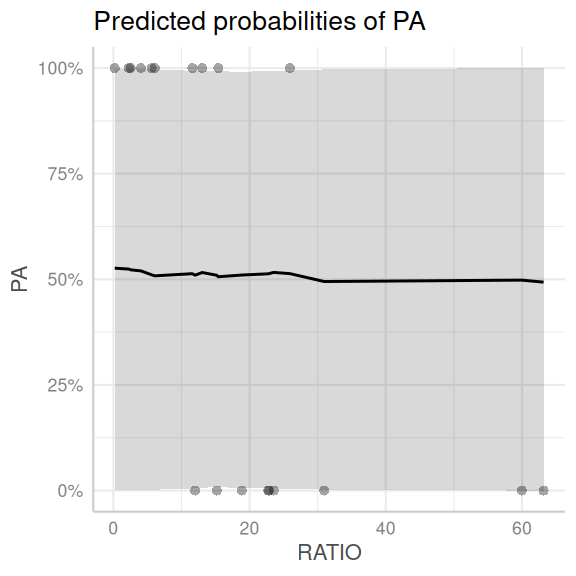

```r
ggemmeans(polis.rstanarm1, ~RATIO) |> plot(show_data = TRUE)
```

**Conclusions:**

- we see that the range of predictions is very wide and the slope could range from strongly negative to strongly positive.

**Defining priors**

The following link provides some guidance about defining priors. [https://github.com/stan-dev/stan/wiki/Prior-Choice-Recommendations]

When defining our own priors, we typically do not want them to be scaled.

If we wanted to define our own priors that were less vague, yet still not likely to bias the outcomes, we could try the following priors (mainly plucked out of thin air):

- $\beta_0$: normal centred at 0 with a standard deviation of 2.5
  - mean: 0 - because the mean response when predictors are centred should be approx. 0.5 (which is 0 on logit scale)
  - sd: 2.5 - since this represents wide priors on logit scale
- $\beta_1$: normal centred at 0 with a standard deviation of 0.1
  - sd: 0.1 - since (`2.5 * sd(polis$PA)/sd(polis$RATIO)`)

I will also overlay the raw data for comparison.

```r
polis.rstanarm2 <- stan_glm(PA ~ RATIO,
  data = polis,
  family = binomial(),
  prior_intercept = normal(0, 2.5, autoscale = FALSE),
  prior = normal(0, 0.1, autoscale = FALSE),
  prior_PD = TRUE,
  iter = 5000, warmup = 1000,
  chains = 3, thin = 5, refresh = 0
)
```

```
Data points may overlap. Use the `jitter` argument to add some amount of
  random variation to the location of data points and avoid overplotting.
```

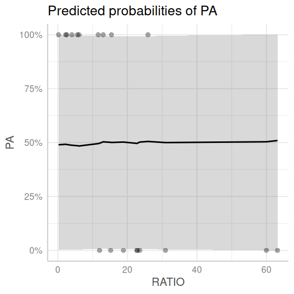

```r
ggemmeans(polis.rstanarm2, ~RATIO) |>
  plot(show_data = TRUE)
```

Now lets refit, conditioning on the data.

```r
polis.rstanarm3 <- update(polis.rstanarm2, prior_PD = FALSE)
```

**Plotting prior and posterior**

```
Drawing from prior...
```

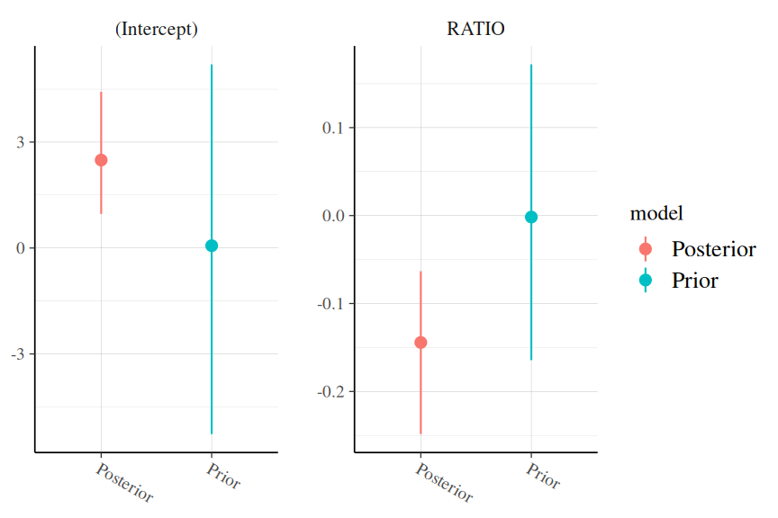

```r
posterior_vs_prior(polis.rstanarm3,
  color_by = "vs", group_by = TRUE,
  facet_args = list(scales = "free_y")
)
```

**Conclusions:**

- in each case, the prior is substantially wider than the posterior, suggesting that the posterior is not biased towards the prior.

```
Data points may overlap. Use the `jitter` argument to add some amount of
  random variation to the location of data points and avoid overplotting.
```

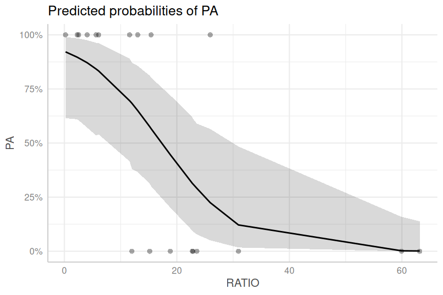

```r
ggemmeans(polis.rstanarm3, ~RATIO) |> plot(show_data = TRUE)
```

```
Data points may overlap. Use the `jitter` argument to add some amount of
  random variation to the location of data points and avoid overplotting.
Data points may overlap. Use the `jitter` argument to add some amount of
  random variation to the location of data points and avoid overplotting.
```

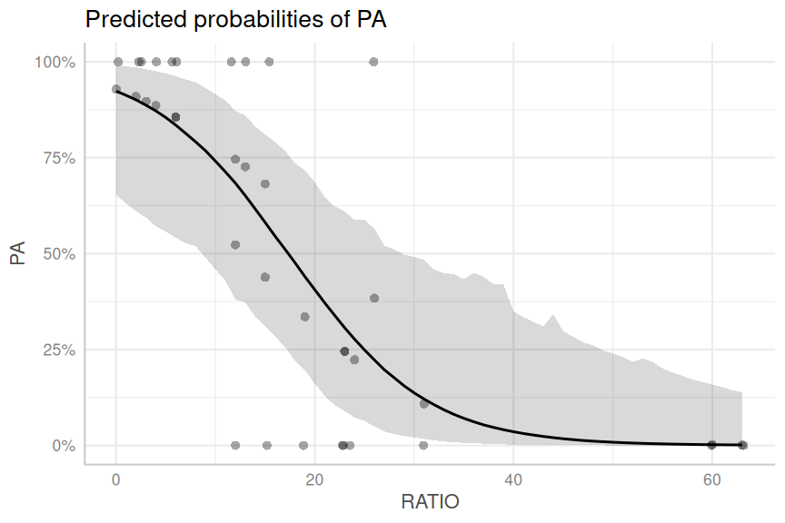

```r
ggemmeans(polis.rstanarm3, terms = "RATIO[0:63]") |>
  plot(
    show_data = TRUE,
    show_residuals = TRUE,
    jitter = FALSE
  )
```

```
Data points may overlap. Use the `jitter` argument to add some amount of
  random variation to the location of data points and avoid overplotting.
```

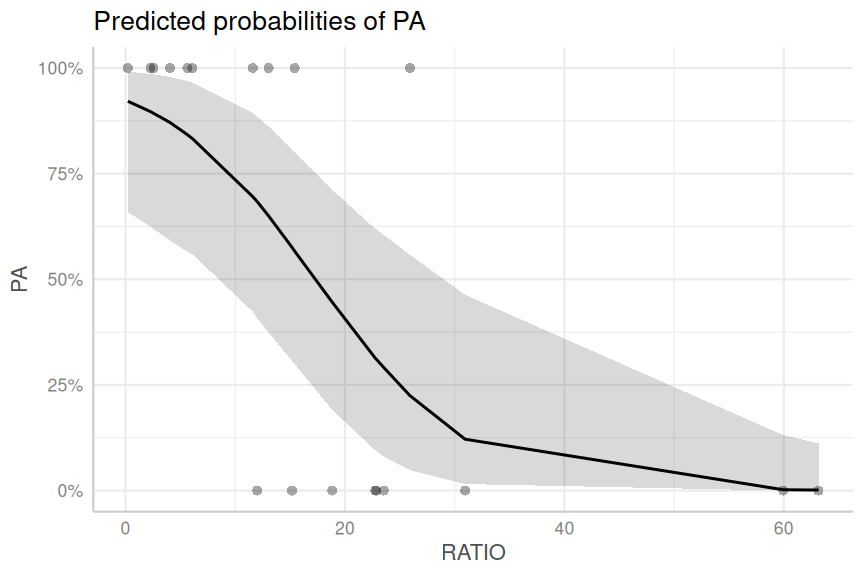

```r
# OR
polis.rstanarm3 |>
  ggpredict(~RATIO) |>
  plot(show_data = TRUE)
```

**brms**

**Using default priors**

In `brms`, the default priors are designed to be weakly informative. They are chosen to provide moderate regularisation (to help prevent over fitting) and help stabilise the computations.

Unlike `rstanarm`, `brms` models must be compiled before they start sampling. For most models, the compilation of the stan code takes around 45 seconds.

```r
form <- bf(PA | trials(1) ~ RATIO, family = binomial())
# OR
form <- bf(PA ~ RATIO, family = bernoulli())
polis_brm <- brm(form,
  data = polis,
  iter = 5000,
  warmup = 1000,
  chains = 3, cores = 3,
  thin = 5,
  refresh = 0,
  backend = "rstan"
)
```

Having allowed `brms` to formulate its own weakly informative priors, it is a good idea to explore what they are. Firstly, out of curiosity, it might be interesting to see what it has chosen. However, more importantly, we need to be able to document what the priors were and the `brms` development team make it very clear that there is no guarantee that the default priors will remain the same into the future.

```r
polis_brm |> prior_summary()
```

```
                prior     class  coef group resp dpar nlpar lb ub       source
               (flat)         b                                        default
               (flat)         b RATIO                             (vectorized)
 student_t(3, 0, 2.5) Intercept                                        default
```

This tells us:

- for the intercept, it is using a student t (flatter normal) prior with a mean of 0 and a standard deviation of 2.5. These are the defaults used for a binomial model. The mean of the response is approximately 0.53. All priors are applied on the link scale (which by default for logistic regression is logit). `brms` takes the view that if the predictors are centred (which they are by default), the mean of the response will be close to 0.5. On the logit scale, this equates to a value of 0. Hence, the prior on intercept is defined as a normal prior with a mean of 0. For logistic regression, the response values must all be either 0 or 1. On the logit scale, values can range from -Inf to Inf. Nevertheless, values on the logit scale that exceed 2.5 in magnitude equate to value on the response scale of either very high or very low (if negative). `brms` therefore uses a standard deviation of 2.5 for the normal prior on the intercept.
- for the beta coefficients (in this case, just the slope), the default prior is a improper flat prior. A flat prior essentially means that any value between negative infinity and positive infinity are equally likely. Whilst this might seem reckless, in practice, it seems to work reasonably well for non-intercept beta parameters.
- there are no distributional parameters in a binomial model and therefore there are no additional priors.

**Assessing priors**

One way to assess the priors is to have the MCMC sampler sample purely from the prior predictive distribution without conditioning on the observed data. Doing so provides a glimpse at the range of predictions possible under the priors. On the one hand, wide ranging predictions would ensure that the priors are unlikely to influence the actual predictions once they are conditioned on the data. On the other hand, if they are too wide, the sampler is being permitted to traverse into regions of parameter space that are not logically possible in the context of the actual underlying ecological context. Not only could this mean that illogical parameter estimates are possible, when the sampler is traversing regions of parameter space that are not supported by the actual data, the sampler can become unstable and have difficulty.

In `brms`, we can inform the sampler to draw from the prior predictive distribution instead of conditioning on the response, by running the model with the `sample_prior='only'` argument. Unfortunately, this cannot be applied when there are flat priors (since the posteriors will necessarily extend to negative and positive infinity). Therefore, in order to use this useful routine, we need to make sure that we have defined a proper prior for all parameters.

In this case, we will define alternative priors for the slope. Default priors for the intercept are already provided (should we wish to use them).

```r
form <- bf(PA | trials(1) ~ RATIO, family = binomial())
# OR
polis_form <- bf(PA ~ RATIO, family = bernoulli())
priors <- prior(normal(0, 2.5), class = "Intercept") +
  prior(normal(0, 1), class = "b")
polis_brm1 <- brm(polis_form,
  data = polis,
  prior = priors,
  sample_prior = "only",
  iter = 5000,
  warmup = 1000,
  chains = 3, cores = 3,
  thin = 5,
  refresh = 0,
  backend = "rstan"
)
```

The following are unlikely to be that useful as the predictions must be bound to the range of [0,1]. Hence, it will be difficult to assess whether the priors could result in very large or small predictions.

```
Data points may overlap. Use the `jitter` argument to add some amount of
  random variation to the location of data points and avoid overplotting.
```

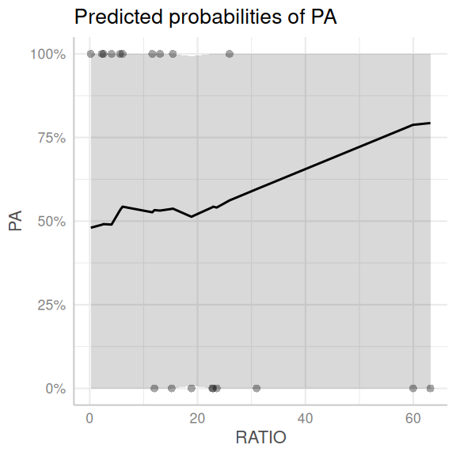

```r
polis_brm1 |>
  ggemmeans(~RATIO) |>
  plot(show_data = TRUE)
```

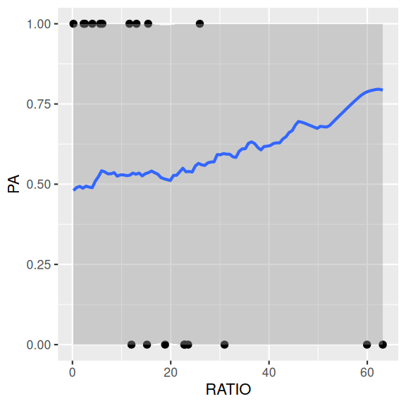

```r
polis_brm1 |>
  conditional_effects() |>
  plot(points = TRUE)
```

**Conclusions:**

- we see that the range of predictions is fairly wide and the slope could range from strongly negative to strongly positive.

**Defining priors**

The following link provides some guidance about defining priors. [https://github.com/stan-dev/stan/wiki/Prior-Choice-Recommendations]

When defining our own priors, we typically do not want them to be scaled.

If we wanted to define our own priors that were less vague, yet still not likely to bias the outcomes, we could try the following priors (mainly plucked out of thin air):

- $\beta_0$: normal centred at 0 with a standard deviation of 2.5
  - mean: 0 - because the mean response when predictors are centred should be approx. 0.5 (which is 0 on logit scale) - 0
  - sd: 2.5 - since this represents wide priors on logit scale
- $\beta_1$: normal centred at 0 with a standard deviation of 0.1
  - sd: 0.1 - since (`2.5 * sd(polis$PA)/sd(polis$RATIO)`)

I will also overlay the raw data for comparison.

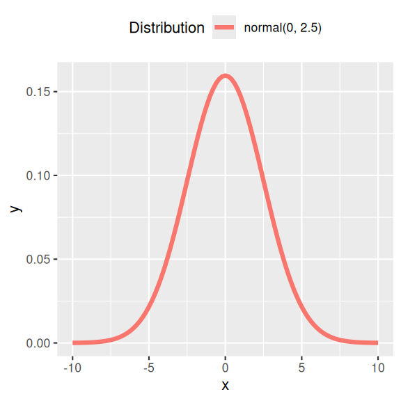

```r
standist::visualize("normal(0, 2.5)", xlim = c(-10, 10))
```

Although this does allow us to visualise what the this looks like on the link (logit) scale, it is hard to appreciate how this relates to the response (real values) scale. To explore this, we must simulate sampling from a normal distribution, transform the normal and plot that density distribution

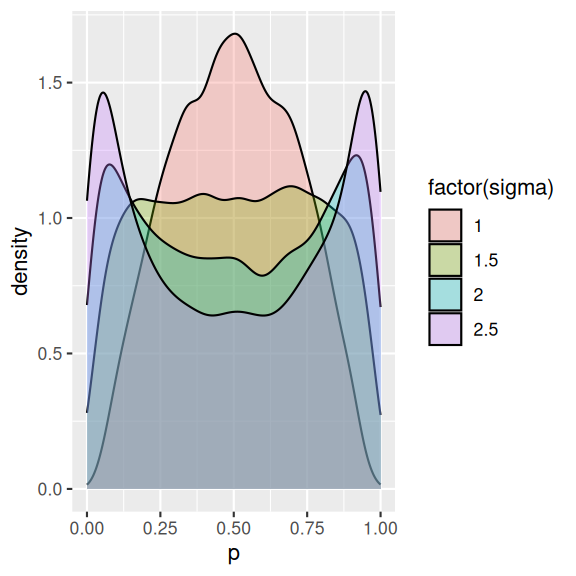

```r
dat <- data.frame(sigma = c(2.5, 2, 1.5, 1))
dat <- dat |>
  group_by(sigma) |>
  reframe(
    r = rnorm(10000, 0, sigma),
    p = plogis(r)
  )
ggplot(dat, aes(x = p)) +
  geom_density(aes(fill = factor(sigma)), alpha = 0.3)
```

Hence, it appears that a prior with a standard deviation of 2.5 would indicate that we believe that probabilities close to either 0 or 1 are the most likely.

So if the predictors are centered (or scaled), we might expect the intercept to represent a probability of approximately 0.5 (and thus presumably close to the switch point). This would seem inappropriate. When this is the case, we want to use a standard deviation of the intercept prior of 1.

On the other hand, if we do not scale the predictor, we might expect the intercept to represent a probability close to either 0 or 1. When this is the case, we want to use a standard deviation of the intercept prior of 2.5.

```r
polis_form <- bf(PA | trials(1) ~ RATIO, family = binomial())
# OR
polis_form <- bf(PA ~ RATIO, family = bernoulli())
priors <- prior(normal(0, 1), class = "Intercept") +
  prior(normal(0, 0.1), class = "b")

polis_brm2 <- brm(polis_form,
  data = polis,
  prior = priors,
  sample_prior = "only",
  iter = 5000,
  warmup = 1000,
  chains = 3, cores = 3,
  thin = 5,
  refresh = 0,
  backend = "rstan"
)
```

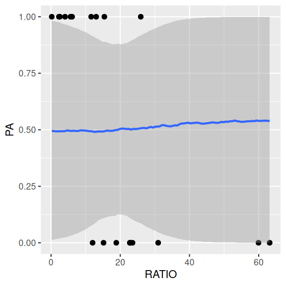

```r
polis_brm2 |>
  conditional_effects() |>
  plot(points = TRUE)
```

```
Data points may overlap. Use the `jitter` argument to add some amount of
  random variation to the location of data points and avoid overplotting.
```

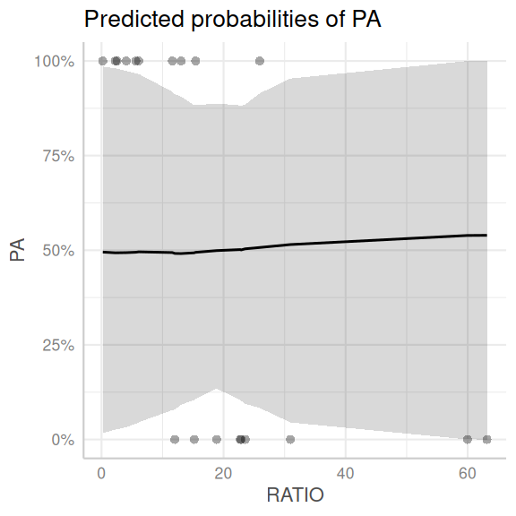

```r
ggemmeans(polis_brm2, ~RATIO) |>
  plot(show_data = TRUE)
```

```r
polis_brm3 <- polis_brm2 |> update(sample_prior = "yes", refresh = 0)
```

```
The desired updates require recompiling the model
```

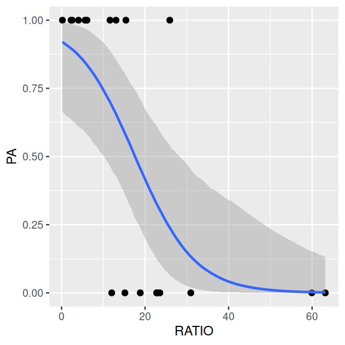

```r
polis_brm3 |>
  conditional_effects() |>
  plot(points = TRUE)
```

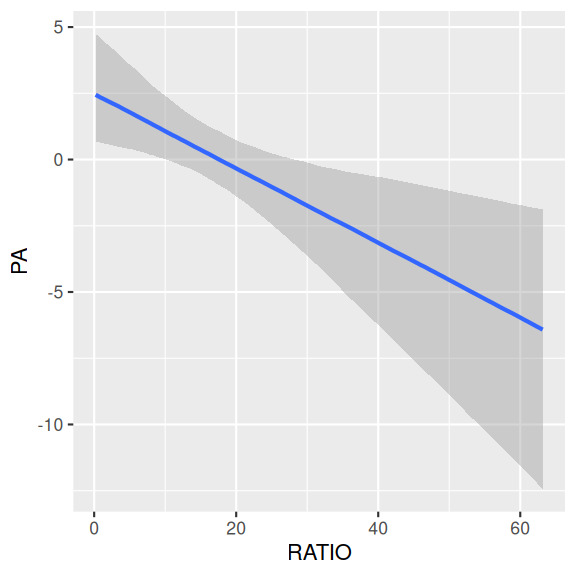

```r
## To see the fitted trend on the scale of the link function
## E.g. to see that it is a straight line
polis_brm3 |> conditional_effects(method = "posterior_linpred")
```

```
Data points may overlap. Use the `jitter` argument to add some amount of
  random variation to the location of data points and avoid overplotting.
```

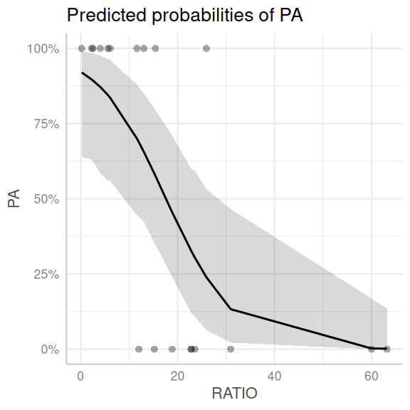

```r
ggemmeans(polis_brm3, ~RATIO) |>
  plot(show_data = TRUE)
```

```
Data points may overlap. Use the `jitter` argument to add some amount of
  random variation to the location of data points and avoid overplotting.
```

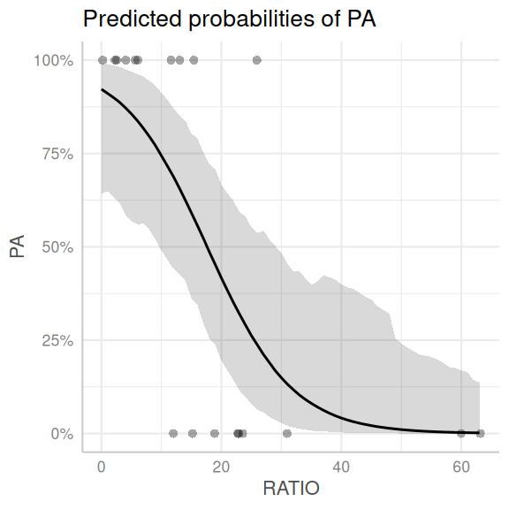

```r
ggemmeans(polis_brm3, terms = "RATIO[0:63]") |>
  plot(show_data = TRUE)
```

**Plotting prior and posterior**

```r
polis_brm3 |> get_variables()
```

```
 [1] "b_Intercept"     "b_RATIO"         "Intercept"       "prior_Intercept"
 [5] "prior_b"         "lprior"          "lp__"            "accept_stat__"
 [9] "stepsize__"      "treedepth__"     "n_leapfrog__"    "divergent__"
[13] "energy__"
```

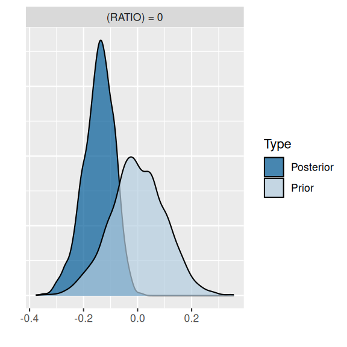

```r
## polis_brm3 |> hypothesis('Intercept=0', class='b') |> plot()
polis_brm3 |>
  hypothesis("RATIO=0") |>
  plot()
```

```r
polis_brm3 |> get_variables()
```

```
 [1] "b_Intercept"     "b_RATIO"         "Intercept"       "prior_Intercept"
 [5] "prior_b"         "lprior"          "lp__"            "accept_stat__"
 [9] "stepsize__"      "treedepth__"     "n_leapfrog__"    "divergent__"
[13] "energy__"
```

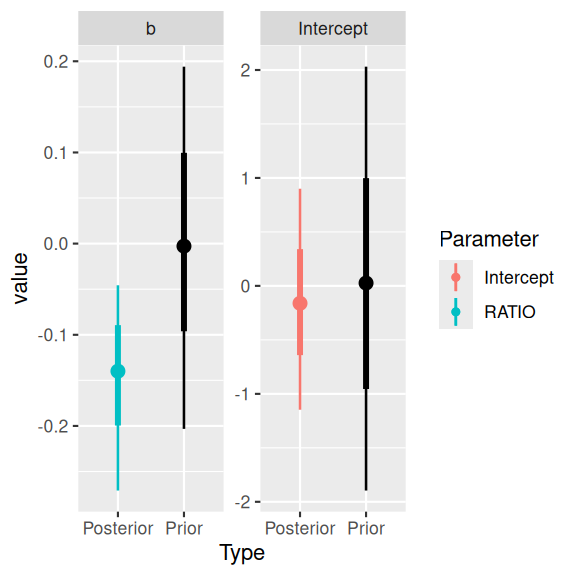

```r
polis_brm3 |> SUYR_prior_and_posterior()
```

**Exploring the stan code**

```r
polis_brm3 |> standata()
```

```
$N
[1] 19

$Y
 [1] 1 1 1 0 1 0 0 0 0 1 1 1 1 0 0 0 0 1 1

$K
[1] 2

$Kc
[1] 1

$X
   Intercept RATIO
1          1 15.41
2          1  5.63
3          1 25.92
4          1 15.17
5          1 13.04
6          1 18.85
7          1 30.95
8          1 22.87
9          1 12.01
10         1 11.60
11         1  6.09
12         1  2.28
13         1  4.05
14         1 59.94
15         1 63.16
16         1 22.76
17         1 23.54
18         1  0.21
19         1  2.55
attr(,"assign")
[1] 0 1

$prior_only
[1] 0

attr(,"class")
[1] "standata" "list"
```

```r
polis_brm3 |> stancode()
```

```
// generated with brms 2.22.0
functions {
}
data {
  int<lower=1> N;  // total number of observations
  array[N] int Y;  // response variable
  int<lower=1> K;  // number of population-level effects
  matrix[N, K] X;  // population-level design matrix
  int<lower=1> Kc;  // number of population-level effects after centering
  int prior_only;  // should the likelihood be ignored?
}
transformed data {
  matrix[N, Kc] Xc;  // centered version of X without an intercept
  vector[Kc] means_X;  // column means of X before centering
  for (i in 2:K) {
    means_X[i - 1] = mean(X[, i]);
    Xc[, i - 1] = X[, i] - means_X[i - 1];
  }
}
parameters {
  vector[Kc] b;  // regression coefficients
  real Intercept;  // temporary intercept for centered predictors
}
transformed parameters {
  real lprior = 0;  // prior contributions to the log posterior
  lprior += normal_lpdf(b | 0, 0.1);
  lprior += normal_lpdf(Intercept | 0, 1);
}
model {
  // likelihood including constants
  if (!prior_only) {
    target += bernoulli_logit_glm_lpmf(Y | Xc, Intercept, b);
  }
  // priors including constants
  target += lprior;
}
generated quantities {
  // actual population-level intercept
  real b_Intercept = Intercept - dot_product(means_X, b);
  // additionally sample draws from priors
  real prior_b = normal_rng(0,0.1);
  real prior_Intercept = normal_rng(0,1);
}
```

**INLA**

**Using default priors**

In `INLA`, the default priors are designed to be diffuse or weak. They are chosen to provide moderate regularisation (to help prevent over-fitting) and help stabilise the computations.

```r
polis.inla <- inla(PA ~ RATIO,
  data = polis,
  family = "gaussian",
  control.compute = list(config = TRUE, dic = TRUE, waic = TRUE, cpo = TRUE)
)
```

In the above:

- the `formula`, `data` and `family` arguments should be familiar as they are the same as for other models in R.
- `control.compute`: allows us to indicate what additional actions should be performed during the model fitting. In this case, we have indicated:
  - `dic`: Deviance information criterion
  - `waic`: Wantanabe information creterion
  - `cpo`: out-of-sample estimates (measures of fit)
  - `config`: return the full configuration - to allow drawing from the posterior.

```r
polis.inla |> names()
```

```
 [1] "names.fixed"                 "summary.fixed"
 [3] "marginals.fixed"             "summary.lincomb"
 [5] "marginals.lincomb"           "size.lincomb"
 [7] "summary.lincomb.derived"     "marginals.lincomb.derived"
 [9] "size.lincomb.derived"        "mlik"
[11] "cpo"                         "gcpo"
[13] "po"                          "waic"
[15] "residuals"                   "model.random"
[17] "summary.random"              "marginals.random"
[19] "size.random"                 "summary.linear.predictor"
[21] "marginals.linear.predictor"  "summary.fitted.values"
[23] "marginals.fitted.values"     "size.linear.predictor"
[25] "summary.hyperpar"            "marginals.hyperpar"
[27] "internal.summary.hyperpar"   "internal.marginals.hyperpar"
[29] "offset.linear.predictor"     "model.spde2.blc"
[31] "summary.spde2.blc"           "marginals.spde2.blc"
[33] "size.spde2.blc"              "model.spde3.blc"
[35] "summary.spde3.blc"           "marginals.spde3.blc"
[37] "size.spde3.blc"              "logfile"
[39] "misc"                        "dic"
[41] "mode"                        "joint.hyper"
[43] "nhyper"                      "version"
[45] "Q"                           "graph"
[47] "ok"                          "cpu.intern"
[49] "cpu.used"                    "all.hyper"
[51] ".args"                       "call"
[53] "model.matrix"
```

Having allowed `INLA` to formulate its own “minimally informative” priors, it is a good idea to explore what they are. Firstly, out of curiosity, it might be interesting to see what it has chosen. However, more importantly, we need to be able to document what the priors were and the `INLA` development team make it very clear that there is no guarantee that the default priors will remain the same into the future.

In calcutating the posterior mode of hyperparameters, it is efficient to maximising the sum of the (log)-likelihood and the (log)-prior, hence, priors are defined on a log-scale. The canonical prior for variance is the *gamma* prior, hence in `INLA`, this is a *loggamma*.

To explore the default priors used by `INLA`, we can issue the following on the fitted model:

```r
inla.priors.used(polis.inla)
```

```
section=[family]
    tag=[INLA.Data1] component=[gaussian]
        theta1:
            parameter=[log precision]
            prior=[loggamma]
            param=[1e+00, 5e-05]
section=[fixed]
    tag=[(Intercept)] component=[(Intercept)]
        beta:
            parameter=[(Intercept)]
            prior=[normal]
            param=[0, 0]
    tag=[RATIO] component=[RATIO]
        beta:
            parameter=[RATIO]
            prior=[normal]
            param=[0.000, 0.001]
```

The above indicates:

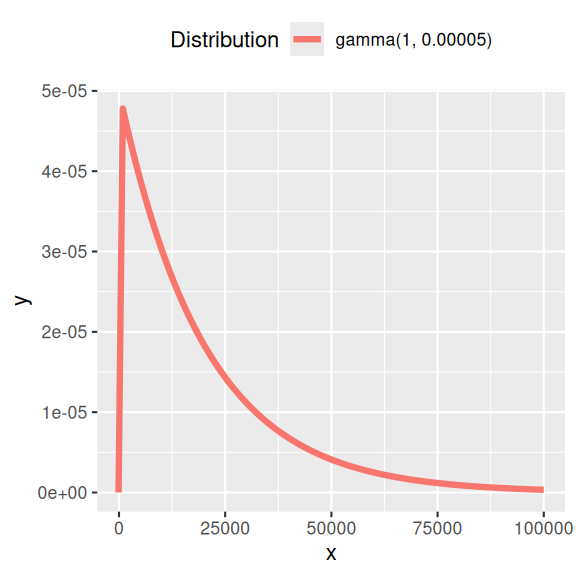

```r
standist::visualize("gamma(1, 0.00005)", xlim=c(-100,100000))
```

- the prior on the intercept is a Gaussian (normal) distribution with mean of 0 and precision of 0 - this is effectively a uniform distribution from $-\infty$ to $\infty$.
- the prior on the slope is a Gaussian (normal) distribution with a mean of 0 and a precision of 0.001 (which equates to a standard deviation of $(1/0.001)^{0.5}$=31.6227766. This is also a very, very wide distribution (consider what a slope large in magnitude of 100 means in the context of the rate of probability of being present increase per unit increase in perimeter to area ratio and on a log odds scale).

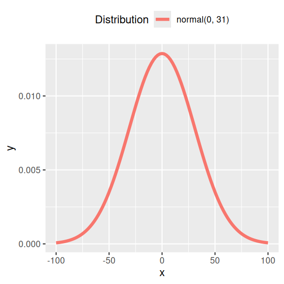

```r
standist::visualize("normal(0, 31)", xlim=c(-100,100))
```

**Defining own priors**

**Family variance**

No existent

**Intercept**

The default prior on the intercept is a Gaussian with mean of 0 and precision of 0 (and thus effectively a flat uniform). Alternatively, we could define priors on the intercept that are more realistic. For example, we know that the middle probability of *Uta* lizard presence is likely to be close to 0.5 0.5263158. However, the parameters are all on a logit scale. Hence a sensible prior would be `log(0.5/(1-0.5))` = 0 (if we were to centre `RATIO`).

We also know that the probability cannot extend above 1 and below 0. That is plus or minus 0.5. On the logit scale, this would be equivalent to approximately plus or minus 1.

```r
mean(polis$PA)
```

```
[1] 0.5263158
```

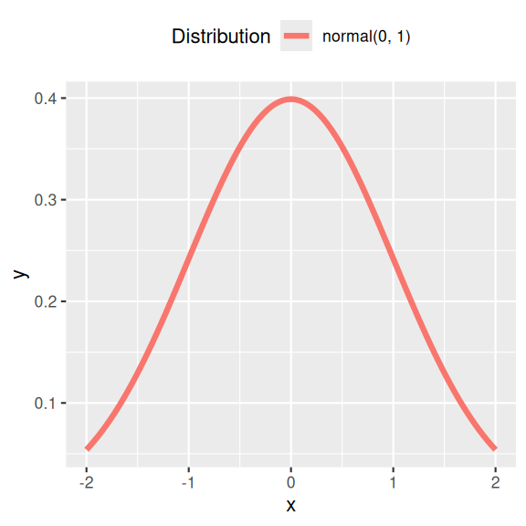

```r
standist::visualize("normal(0, 1)", xlim=c(-2,2))
```

We could use these values as the basis for weekly informative priors on the intercept. Note, as `INLA` priors are expressed in terms of precision rather than variance, an equvilent prior would be $\sim{}~\mathcal{N}(0, 1)$ (e.g. $1/(1)^2$).

**Fixed effects**

The priors for the fixed effects (slope) is a Gaussian (normal) distributions with mean of 0 and precision (0.001). This implies that the prior for slope has a standard deviation of approximately 31 (since $\sigma = \frac{1}{\sqrt{\tau}}$). As a general rule, three standard deviations envelopes most of a distribution, and thus this prior defines a distribution whose density is almost entirely within the range [-93,93]. On a logit scale, this is very large.

In order to generate realistic informative Gaussian priors (for the purpose of constraining the posterior to a logical range) for fixed parameters, the following formulae are useful:

$$\begin{align}
\mu &= \frac{z_2\theta_1 - z_1\theta_2}{z_2-z_1}\\
\sigma &= \frac{\theta_2 - \theta_1}{z_2-z_1}
\end{align}$$

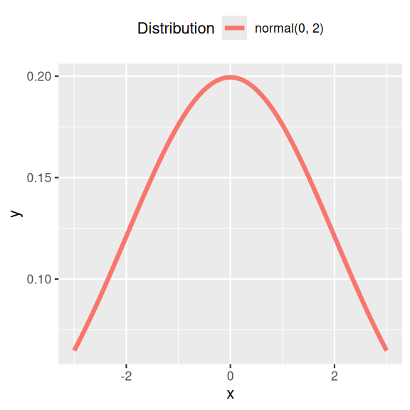

```r
standist::visualize("normal(0, 2)", xlim=c(-3,3))
```

In order to define each of the above priors, we could modify the `inla` call:

```r
polis.inla1 <- inla(PA ~ scale(RATIO, scale = FALSE),
  data = polis,
  Ntrials = 1,
  family = "binomial",
  control.fixed = list(
    mean.intercept = 0,
    prec.intercept = 0.01,
    mean = 0,
    prec = 0.25
  ),
  control.compute = list(config = TRUE, dic = TRUE, waic = TRUE, cpo = TRUE)
)
```

# 6 MCMC sampling diagnostics

**rstanarm**

**bayesplot**

The `bayesplot` package offers a range of MCMC diagnostics as well as Posterior Probability Checks (PPC), all of which have a convenient `plot()` interface. Lets start with the MCMC diagnostics.

**See list of available diagnostics by name**

```r
available_mcmc()
```

```
bayesplot MCMC module:
  mcmc_acf
  mcmc_acf_bar
  mcmc_areas
  mcmc_areas_ridges
  mcmc_combo
  mcmc_dens
  mcmc_dens_chains
  mcmc_dens_overlay
  mcmc_hex
  mcmc_hist
  mcmc_hist_by_chain
  mcmc_intervals
  mcmc_neff
  mcmc_neff_hist
  mcmc_nuts_acceptance
  mcmc_nuts_divergence
  mcmc_nuts_energy
  mcmc_nuts_stepsize
  mcmc_nuts_treedepth
  mcmc_pairs
  mcmc_parcoord
  mcmc_rank_ecdf
  mcmc_rank_hist
  mcmc_rank_overlay
  mcmc_recover_hist
  mcmc_recover_intervals
  mcmc_recover_scatter
  mcmc_rhat
  mcmc_rhat_hist
  mcmc_scatter
  mcmc_trace
  mcmc_trace_highlight
  mcmc_violin
```

Of these, we will focus on:

- mcmc_trace: this plots the estimates of each parameter over the post-warmup length of each MCMC chain. Each chain is plotted in a different shade of blue, with each parameter in its own facet. Ideally, each **trace** should just look like noise without any discernible drift and each of the traces for a specific parameter should look the same (i.e, should not be displaced above or below any other trace for that parameter).

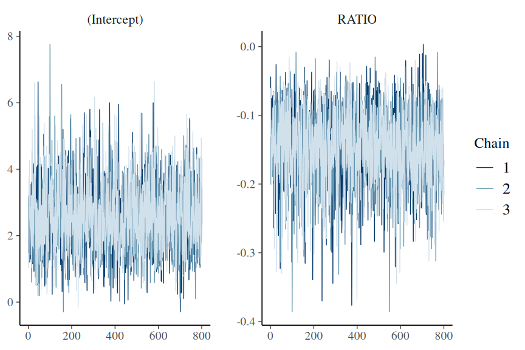

```r
plot(polis.rstanarm3, plotfun = "mcmc_trace")
```

The chains appear well mixed and very similar

- acf (auto-correlation function): plots the auto-correlation between successive MCMC sample lags for each parameter and each chain

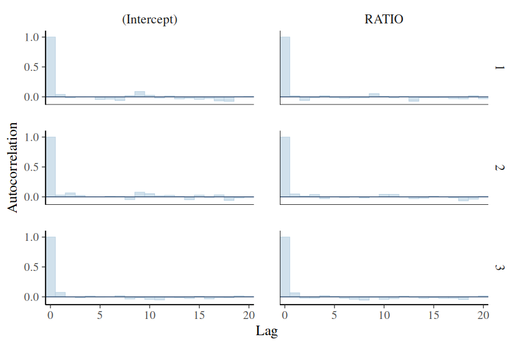

```r
plot(polis.rstanarm3, "acf_bar")
```

There is no evidence of auto-correlation in the MCMC samples

- Rhat: Rhat is a measure of convergence between the chains. The closer the values are to 1, the more the chains have converged. Values greater than 1.05 indicate a lack of convergence. There will be an Rhat value for each parameter estimated.

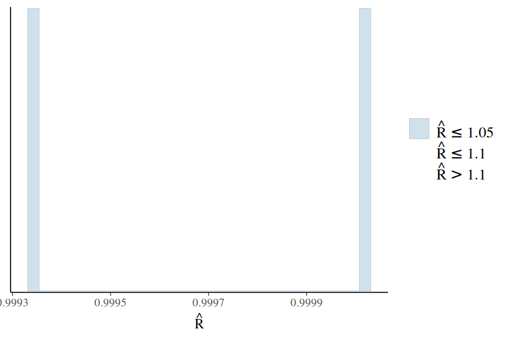

```r
plot(polis.rstanarm3, "rhat_hist")
```

All Rhat values are below 1.05, suggesting the chains have converged.

- neff (number of effective samples): the ratio of the number of effective samples (those not rejected by the sampler) to the number of samples provides an indication of the effectiveness (and efficiency) of the MCMC sampler. Ratios that are less than 0.5 for a parameter suggest that the sampler spent considerable time in difficult areas of the sampling domain and rejected more than half of the samples (replacing them with the previous effective sample).

  If the ratios are low, tightening the priors may help.

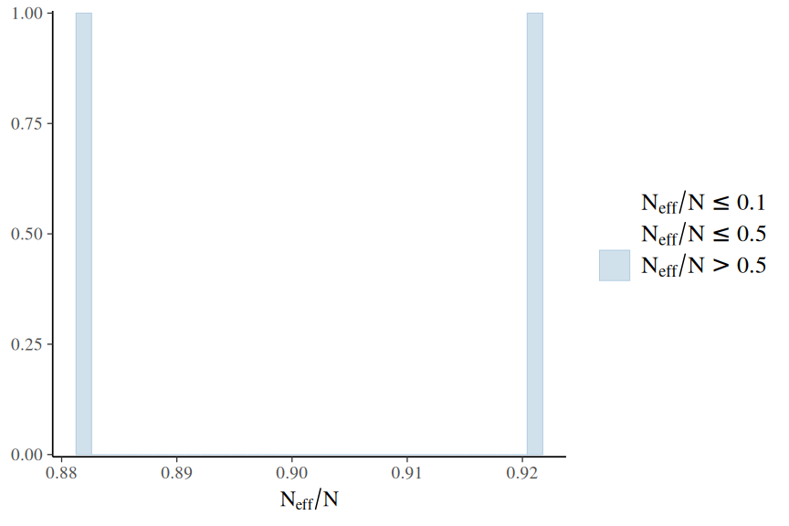

```r
plot(polis.rstanarm3, "neff_hist")
```

Ratios all very high.